# Political (data) Science - Assignment 2

Tony Hui

```r
cat("
<style>
h2 {
  font-size: 24px;
  color:#045a8d;
  text-align:center;
}

h3 {
  font-size: 10px;
  color:#2b8cbe;
  text-align:center;
}

h4 {
  font-size: 14px;
  color:#2b8cbe;
}
</style>
")
```

This homework uses both the Countries and POL201 data sets.

```r
Countries=read.csv("http://www.sfu.ca/~sweldon/Countries.csv")
POL201=read.csv("http://www.sfu.ca/~sweldon/POL201.csv")
```

## Association: Two Categorical Variables

*Research Question: Is there a relationship between political regime (dictator) and level of freedom (fh)?*

**Contingency Tables**

### 1)

#### First, identify the dependent (response) and independent (explanatory) variable. Explain why you identified them the way you did.

nah

### 2)

#### Make a frequency contingency table of dictator and level of freedom. Be sure to add the margins to the table, that is, the totals.

```r
addmargins(table(Countries$dictator, Countries$fh)) %>% kable()
```

|  | 1. Free | 2. Partly Free | 3. Not Free | Sum |
| --- | --- | --- | --- | --- |
| 0. Democracy | 80 | 27 | 2 | 109 |
| 1. Dictatorship | 7 | 26 | 46 | 79 |
| Sum | 87 | 53 | 48 | 188 |

### 3)

#### Do the same as above, but with the conditional proportions or percentages (also called conditional distributions).

```r
addmargins(prop.table(table(Countries$dictator, Countries$fh))) %>% round(3) %>% kable
```

|  | 1. Free | 2. Partly Free | 3. Not Free | Sum |
| --- | --- | --- | --- | --- |
| 0. Democracy | 0.426 | 0.144 | 0.011 | 0.58 |
| 1. Dictatorship | 0.037 | 0.138 | 0.245 | 0.42 |
| Sum | 0.463 | 0.282 | 0.255 | 1.00 |

**Barplots**

### 4)

#### Now, make a stacked barplot of the conditional proportions that shows the relationship between dictator and level of freedom.

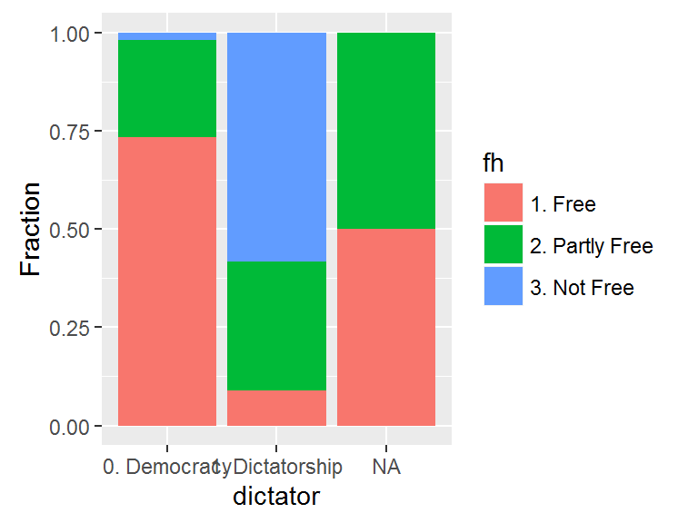

```r
ggplot(Countries, aes(x = dictator, fill = fh)) +
  geom_bar(position = "fill") +
  ylab("Fraction")
```

### 5)

#### Is there a relationship between type of political regime and level of freedom? Explain.

Yes

### 6)

#### Explain with specific reference to trying to answer the research question why conditional proportions are a better way of assessing relationships than raw frequency counts.

## Association: One Categorical, One Numerical Variable

*A side-by-side box plot is useful way of graphing the relationship between a categorical variable and a numeric continuous variable. To do this you want to run separate box plots of the continuous variable for each value or group of the categorical variable.*

*Research Question: Is there a relationship between the degree of freedom (fh) and ethnic fractionalization in a country (efrac)?*

### 7)

#### First, identify the dependent (response) and independent (explanatory) variable. Explain.

Nah

### 8)

#### Make a side-by-side boxplot of the relationship between degree of freedom and ethnic fractionalization from the Countries data set.

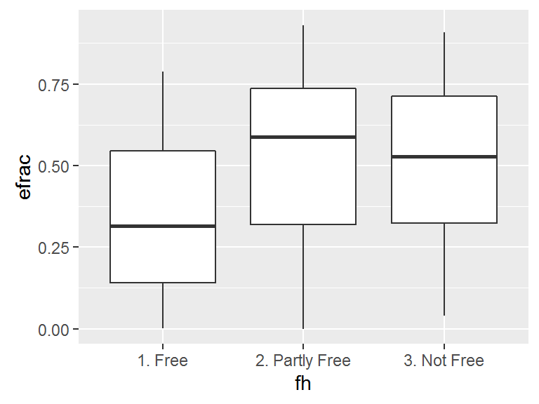

```r
ggplot(Countries, aes(fh, efrac)) +
  geom_boxplot()
```

### 9)

#### Is there a relationship between freedom level and ethnic fractionalization? Is that relationship causal based on the four hurdles of causation? Explain.

Yes

## Association: Two Numeric Variables

*Research Question: Is there a relationship between the level of ethnic fractionalization (efrac) and quality of life (hobbes)?*

### 10)

#### First, identify the dependent (response) and independent (explanatory) variable. Explain.

Nah

### 11)

#### Now, run a scatterplot of the relationship between the 2 variables. Then, find the Pearson correlation coefficient. Interpret the results. That is, is there a relationship? If so, what is the nature of the relationship? Is it strong or weak?

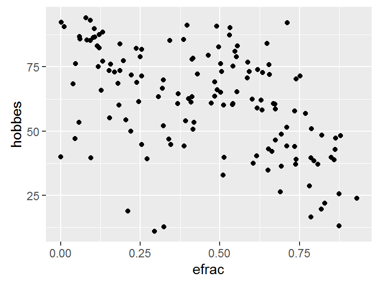

```r
ggplot(Countries, aes(efrac, hobbes)) +
  geom_point()
```

```r
cor(x = Countries$efrac, Countries$hobbes, use = "complete")
```

```
## [1] -0.4867376
```

### 12)

#### Is this relationship causal? Explain.

Correlation is not causation (I’m sure you’ve heard of this basically)

*Research Question: Using the POL201 data set, is there a relationship between the time that students report studying for each class and their GPA?*

### 13)

#### Identify the dependent (response) and independent (explanatory) variable. Explain.

Nah

### 14)

#### Now, run a scatterplot of the relationship between the two variables. Then, find the Pearson correlation coefficient. Again, interpret the results.

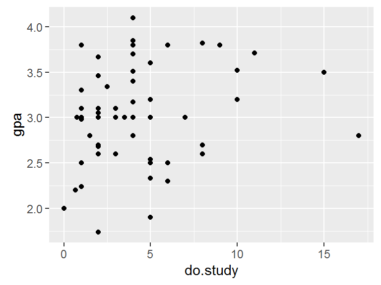

```r
ggplot(POL201, aes(do.study, gpa)) +
  geom_point()
```

```r
cor(POL201$do.study, POL201$gpa, use="complete")
```

```
## [1] 0.2240582
```

## Linear Regression

### 15)

#### Looking again at the relationship between the amount of time students report studying for each class and their GPA. Run a linear regression. Interpret the results. In particular, what additional information do you now have that you did not with just the scatterplot/correlation?

```r
lm(formula = gpa ~ do.study, data = POL201)
```

```
##
## Call:
## lm(formula = gpa ~ do.study, data = POL201)
##
## Coefficients:
## (Intercept)     do.study
##     2.88272      0.03476
```

### 16)

#### A linear regression can be used for prediction. In particular, if you know values on the independent variable(s), you can predict the value for the dependent variable. Let’s say you were chatting with a friend who was a university student and she told you that she spent 9.5 hours per week, on average, studying for each course. Based on this information and your results from Question ##15, predict this student’s GPA.

```r
x <- 9.5
(y = 0.03476*x + 2.88272)
```

```
## [1] 3.21294
```

*Now, let’s test this little equation out! Find a friend or any student, one who is not in this class. First, ask them how much time they think students should spend studying and completing assignments for each course per week. Then, ask them how much time they personally spend actually studying and completing assignments for each class per week.*

For fun let’s use me. I study 10 hours a week. I think people should study around 10 hours a week. I have a GPA of 4.0

### 17)

#### Using the amount of time your interviewee thinks that students should spend studying per week and the results from Question ##14, predict how much time the interviewee actually spends studying. Compare that to what the interviewee reported. How good was the linear regression equation at predicting your interviewee’s time spent actually studying?

This question is confusing. I thought `should study` was irrelevant?

```r
y = 4
(x = (y-3.21294)/0.03476)
```

```
## [1] 22.64269
```

**A little review from last week**

### 18)

#### Based on the sample of student heights (height) from the POL201 data set, calculate the z-score, also called standard score, for Yao Ming, a 7’6” former basketball player who played for the Houston Rockets.

Is your prof american? Anyway, 7’6" is 90 inches

```r
(90 - mean(POL201$height, na.rm = T))/sd(POL201$height, na.rm = T)
```

```
## [1] 5.466696
```

### 19)

#### Thinking about the relationship between samples and populations, do you think the z-score you calculated above for Yao Ming would be the same if you had calculated it from a sample of professional basketball players? Why or why not? What about a sample of world’s population? Why or why not? Which would be the more appropriate sample to use to calculate the z-score for Yao Ming’s height? Explain.

z-score is based on the sampled mean and standard deviation. Sampling different shit gives different means and standard deviations

## Some fun

What exactly is the best predictor of GPA in pol201?

#### Check correlations

```r
nums <- sapply(POL201, is.numeric) %>% subset(.,.) %>% names
pol201_num <- POL201[,nums]
x <- cor(pol201_num, use = "pairwise", method = "spear")[,"gpa"] %>% sort %>% data.frame %>% data.table::setnames("correlation")
x
```

```
##             correlation
## texts      -0.342313086
## facebook   -0.278090923
## idlgy      -0.228835453
## kiss       -0.067396591
## haircut    -0.021575955
## height      0.002836694
## siblings    0.078089684
## happy       0.103825533
## credit.hrs  0.130890742
## shld.study  0.157997838
## africa.per  0.172690608
## do.study    0.229061512
## gpa         1.000000000
```

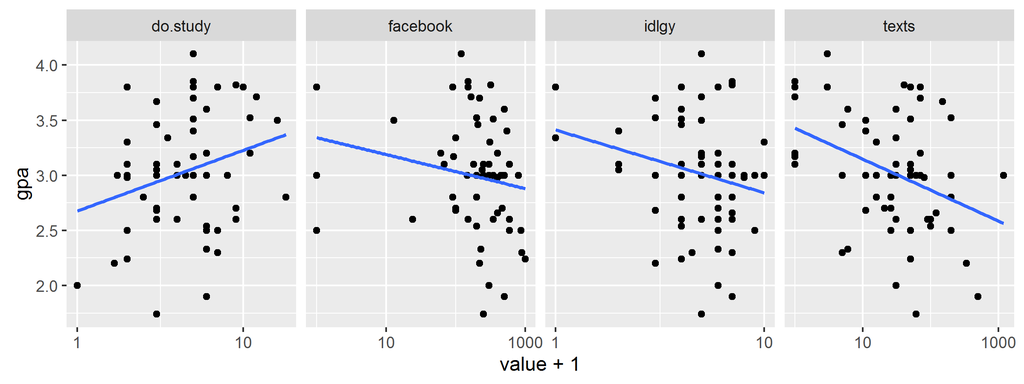

```r
x <- x %>% subset(abs(correlation) > 0.2)

POL201[,rownames(x)] %>% gather(key, value, -gpa) %>% tbl_df() %>%
ggplot(aes(value+1, gpa)) +
  geom_point() +
  geom_smooth(method="lm", se = F) +
  facet_wrap(~key, scales = "free_x", nrow=1) +
  scale_x_log10()
```

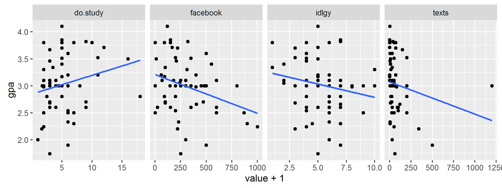

```r
POL201[,rownames(x)] %>% gather(key, value, -gpa) %>% tbl_df() %>%
ggplot(aes(value+1, gpa)) +
  geom_point() +
  geom_smooth(method="lm", se = F) +
  facet_wrap(~key, scales = "free_x", nrow=1)
```

```r
## Predict
formula <- as.formula(paste("gpa ~", paste(colnames(pol201_full) %>% subset(. != "gpa"), collapse = "+")))
(model <- lm(formula, pol201_full) %>% anova)

variables_to_consider <- model %>% select(pval = 5) %>% rownames_to_column("variable") %>% mutate(fdr = p.adjust(.[,2], method = "fdr")) %>% arrange(pval) %>% head
(variables_to_consider)
```

[output not shown]

#### Plot Categorical Data

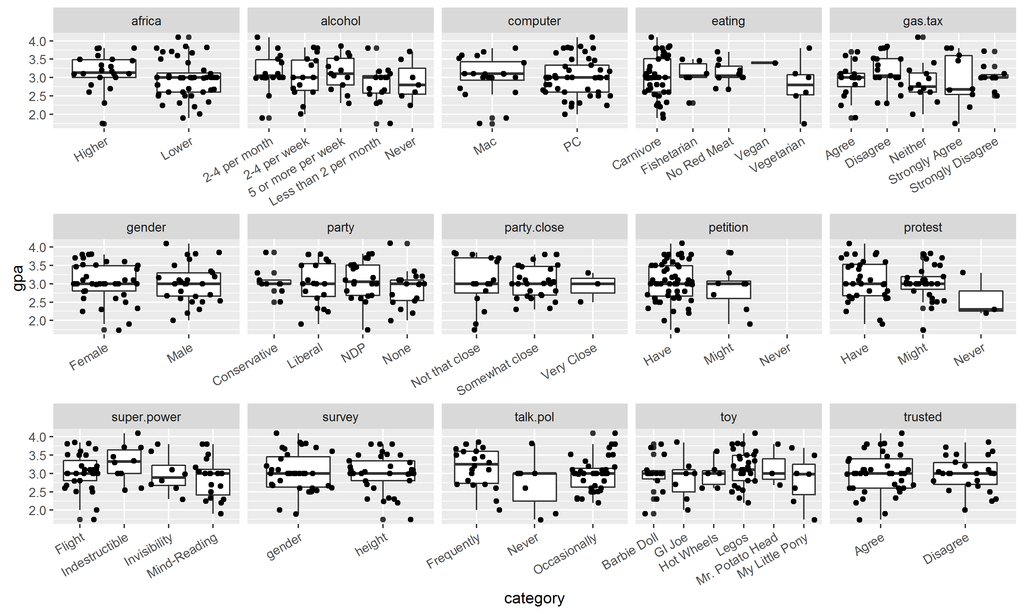

```r
pol201_hits_cat <- POL201 %>% select(-one_of(nums), gpa) %>% gather(column, category, -gpa)

# levels_plot <- pol201_hits_cat$category %>% unique() %>% .[c(4,1,2,3,5,7,9,6,8,10)]

# pol201_hits_cat$category <- factor(pol201_hits_cat$category, levels=levels_plot)

pol201_hits_cat %>%
  ggplot(aes(category, gpa)) +
  geom_boxplot() +
  geom_jitter() +
  geom_smooth(method="lm", se=F) +
  facet_wrap(~column, scales = "free_x", nrow=3) +
  theme(axis.text.x = element_text(angle = 30, hjust = 1))
```

#### Followup on some Categorical Data

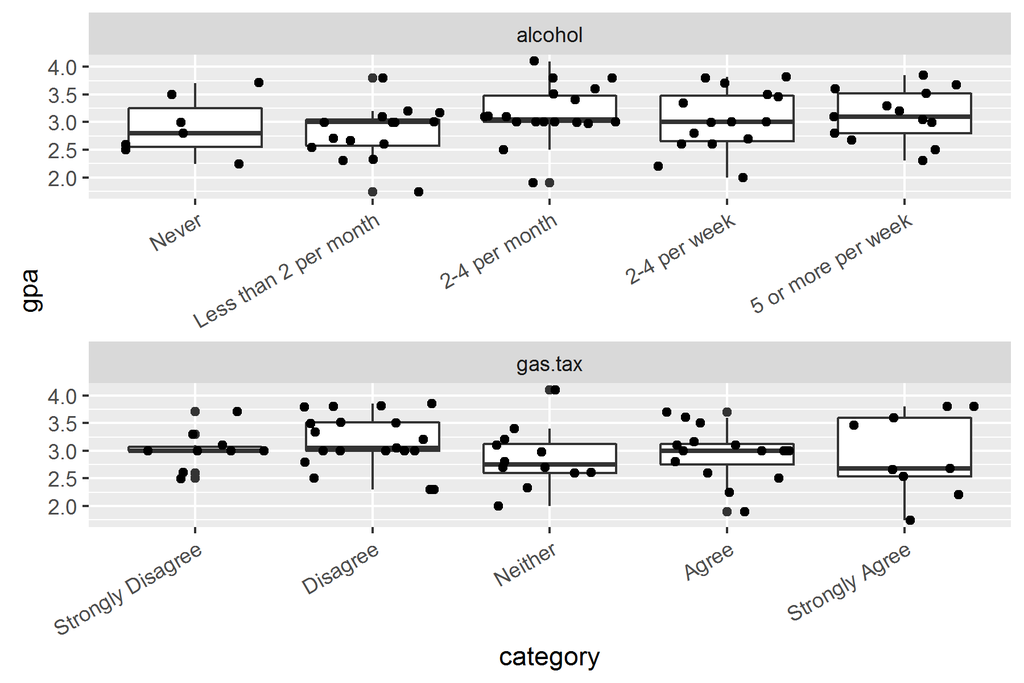

```r
pol201_hits_cat <- POL201 %>% select(gas.tax, alcohol, gpa) %>% gather(column, category, -gpa) %>% filter(!is.na(category))

levels_plot <- pol201_hits_cat$category %>% unique() %>% as.character() %>% sort(decreasing = T) %>% .[c(1,6,4,7,2,3,5,10,9,8)]

pol201_hits_cat$category <- factor(pol201_hits_cat$category, levels=levels_plot)

pol201_hits_cat %>%
  ggplot(aes(category, gpa)) +
  geom_boxplot() +
  geom_jitter() +
  geom_smooth(method="lm", se=F) +
  facet_wrap(~column, scales = "free_x", nrow=3) +
  theme(axis.text.x = element_text(angle = 30, hjust = 1))
```

#### Which variables are related?

```r
categorical <- POL201 %>% select(-one_of(nums))
fisher.test(x = categorical$survey, y = categorical$gender)$p.value
```

```
## [1] 1
```

```r
x<-combn(x = names(categorical), m = 2, FUN = function(x) {
  fisher.test(x = categorical[,x[1]], y = categorical[,x[2]], workspace = 400000, simulate.p.value=TRUE)$p.value
  })

results <- combn(x = names(categorical), m = 2) %>% t %>% cbind(x) %>% as_data_frame() %>% setNames(c("one", "two", "pvalue")) %>% arrange(pvalue) %>% filter(pvalue < 0.01)
results %>% kable()
```

| one | two | pvalue |
| --- | --- | --- |
| gender | alcohol | 0.000499750124937531 |
| gender | toy | 0.000499750124937531 |
| gender | eating | 0.00149925037481259 |
| petition | protest | 0.00349825087456272 |
| gender | party | 0.00649675162418791 |
| party.close | talk.pol | 0.00749625187406297 |
| talk.pol | protest | 0.00899550224887556 |

#### Plot associated categories

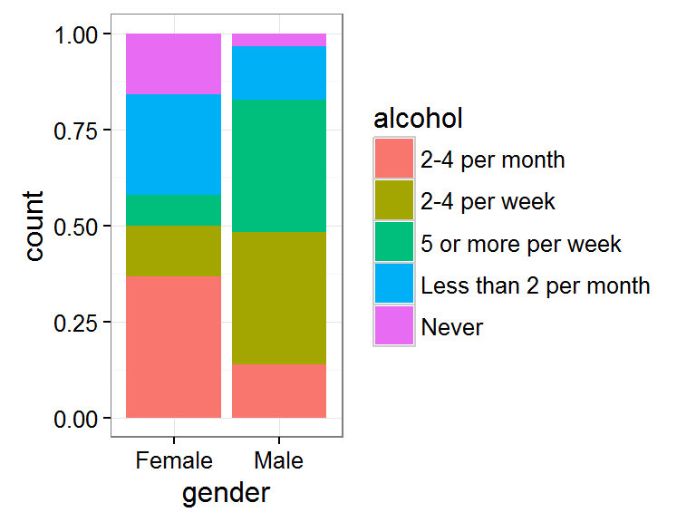

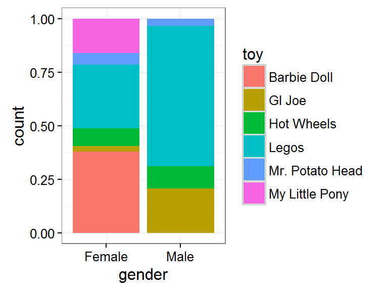

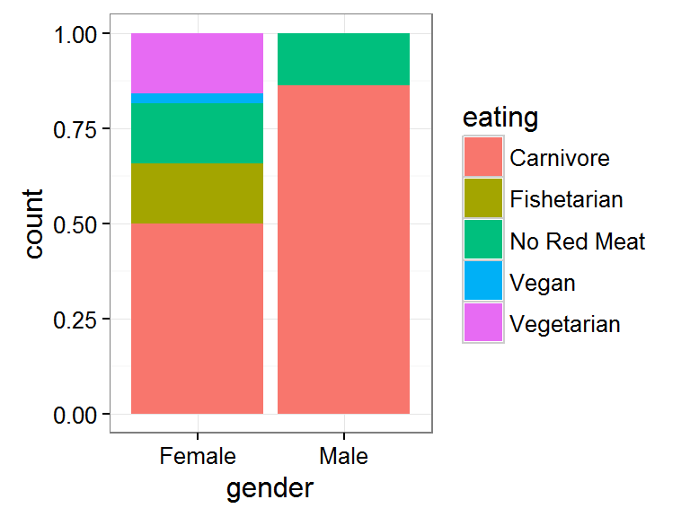

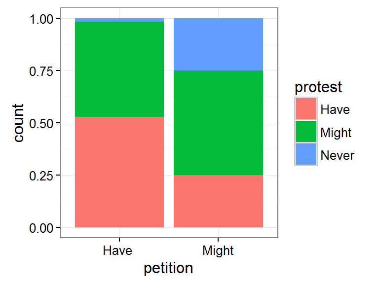

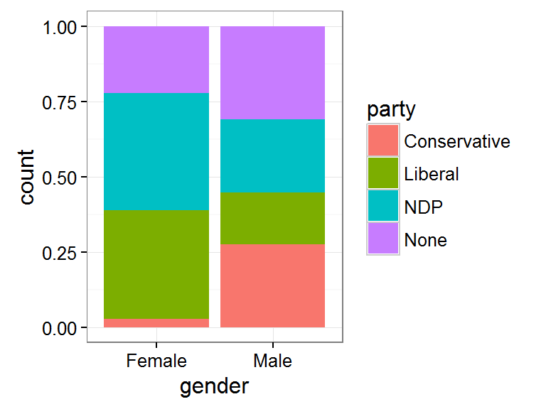

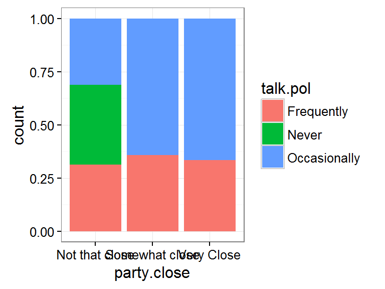

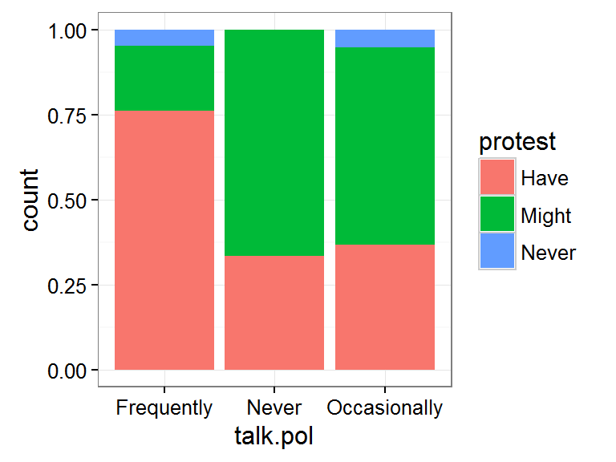

```r
plot_categories <- function(one, two) {
  # one="gender"; two="toy"
  heatmap <- POL201[,c(one, two, "gpa")] %>% filter(!is.na(gpa)) %>% .[complete.cases(.),]
  # %>% group_by(party, party.close) %>% summarize(gpa = mean(gpa))

  p <- heatmap %>%
    ggplot(aes_q(x= as.name(one), fill = as.name(two))) +
    geom_bar(position="fill") +
    theme_bw()
  return(p)
}

for (i in 1:nrow(results)) {
  plot_categories(one=results$one[i], two=results$two[i]) %>% print
}
```